# U.S Medical Insurance Project

### Abstract

For this project I will demonstrate my ability to use various data science techniques and methodologies using technologies such as Python, PowerBI, Jupyter Notebook, and GitHub.

The dataset used for this project can be accessed [here](https://www.kaggle.com/mirichoi0218/insurance).

### Project Goals

To create initial analysis that will determine the population of the dataset to explicitly state any biases within the dataset, such as being weighted towards specific regions or genders.

**Determine:**

1. Average age
2. Average bmi
3. Gender split in %
4. Average number of children
5. Smoker split in %
6. Average cost of insurance
7. Produce graphs to holistically represent the dataset

```python
#imports
import csv
```

```python
#Create empty lists for the various attributes in insurance.csv
age = []
sex = []
bmi = []
children = []
smoker = []
region = []
charges = []
```

```python
#Function to inject data into empty lists
def inject_data(lst, csv_file, column_name):
    with open(csv_file) as csv_info:
        csv_dict = csv.DictReader(csv_info)
        for row in csv_dict:
            lst.append(row[column_name])
        return lst
```

```python
#Run function to inject data into empty lists
inject_data(age, '01 insurancecosts.csv', 'age')
inject_data(sex, '01 insurancecosts.csv', 'sex')
inject_data(bmi, '01 insurancecosts.csv', 'bmi')
inject_data(children, '01 insurancecosts.csv', 'children')
inject_data(smoker, '01 insurancecosts.csv', 'smoker')
inject_data(region, '01 insurancecosts.csv', 'region')
inject_data(charges, '01 insurancecosts.csv', 'charges')
print("Injection Complete")
```

```
Injection Complete
```

```python
#Averages
ages = [int(i) for i in age]
averageage = round(sum(ages) / len(ages))

bmis = [float(x) for x in bmi]
averagebmi = round(sum(bmis) / len(bmis), 2)

females = sex.count('female')
males = sex.count('male')
population_total = males + females
population_female_percentage = '{0:.2%}'.format(females / population_total)
population_male_percentage = '{0:.2%}'.format(males / population_total)

numchildren = [int(y) for y in children]
averagechildren = round(sum(numchildren) / len(children), 2)

smokers = smoker.count('yes')
population_smokers = '{0:.2%}'.format(smokers / population_total)

population_northwest = region.count('northwest')
population_southwest = region.count('southwest')
population_northeast = region.count('northeast')
population_southeast = region.count('southeast')

population_nw_percentage = '{0:.2%}'.format(population_northwest / population_total)
population_sw_percentage = '{0:.2%}'.format(population_southwest / population_total)
population_ne_percentage = '{0:.2%}'.format(population_northeast / population_total)
population_sw_percentage = '{0:.2%}'.format(population_southeast / population_total)

costs = [float(z) for z in charges]
averagecost = round(sum(costs) / len(costs), 2)
```

## Population Analysis

The average age of an individual within the dataset is 39 years of age.

The average bmi of an individual within the data is 30.66.

Females account for 49.48% of the data set, whilst males account for 50.52%.

The average number of children for each adult in the data is 1.09.

20.48% of the data set are smokers.

The average cost for medical insurance in the US is $13,270.42.

### Chart Analysis

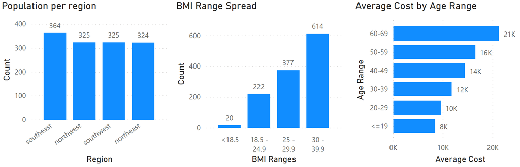

As seen above we can see that the population is relatively spread evenly across each region, however the southeast does represent roughly **11% more of the dataset when compared to the other regions**.

Furthermore, NHS bmi [guidelines](https://www.nhs.uk/common-health-questions/lifestyle/what-is-the-body-mass-index-bmi/) show that **a large number of the dataset is either overweight or obese:**

- below 18.5 – the underweight range
- between 18.5 and 24.9 – the healthy weight range
- between 25 and 29.9 – the overweight range
- between 30 and 39.9 – the obese range

Additionally we can also see that as age increases so does the average cost of insurance, **by the time an individual reaches 60+ they can expect to pay roughly double the medical insurance they were paying at age 20**.

```python
#print('The average age of an individual within the dataset is ' + str(averageage) + ' years of age.\n')
#print('The average bmi of an individual within the data is ' + str(averagebmi) + '.\n')
#print('Females account for ' + str(population_female_percentage) + ' of the data set, whilst males account for ' + str(population_male_percentage + '.\n'))
#print('The average number of children for each adult in the data is ' + (str(averagechildren)) + '.\n')
#print((str(population_smokers) + ' of the data set are smokers.\n'))
#print('The average cost for medical insurance in the US is ' + str(averagecost) + ' dollars.\n')
```